# EOLIA Trial Supplementary Analyses

# Causal Forest (Generalized Random Forests)

Causal forests (Athey, Tibshirani, and Wager 2019) use honest sample splitting to prevent overfitting and provide asymptotically valid inference for individualized treatment effects.

```r
library(grf)

X_mat_grf <- model.matrix(~ . - 1, data = X)

set.seed(GLOBAL_SEED)
cf <- causal_forest(
  X = X_mat_grf,
  Y = y,
  W = as.numeric(z),
  num.trees = 2000,
  honesty = TRUE,
  tune.parameters = "all",
  seed = GLOBAL_SEED
)

cate_grf <- predict(cf)$predictions
cate_grf_var <- predict(cf, estimate.variance = TRUE)$variance.estimates

cat("Causal Forest results:\n")
```

```
## Causal Forest results:
```

```r
cat("Mean CATE:", round(mean(cate_grf), 4),
    "SD:", round(sd(cate_grf), 4),
    "range: [", round(min(cate_grf), 4), ",",
    round(max(cate_grf), 4), "]\n")
```

```
## Mean CATE: -0.0851 SD: 0.005 range: [ -0.0961 , -0.0722 ]
```

```r
cat("ATE estimate:", round(average_treatment_effect(cf)[1], 4),
    "SE:", round(average_treatment_effect(cf)[2], 4), "\n")
```

```
## ATE estimate: -0.1022 SE: 0.0627
```

## Cross-method CATE comparison

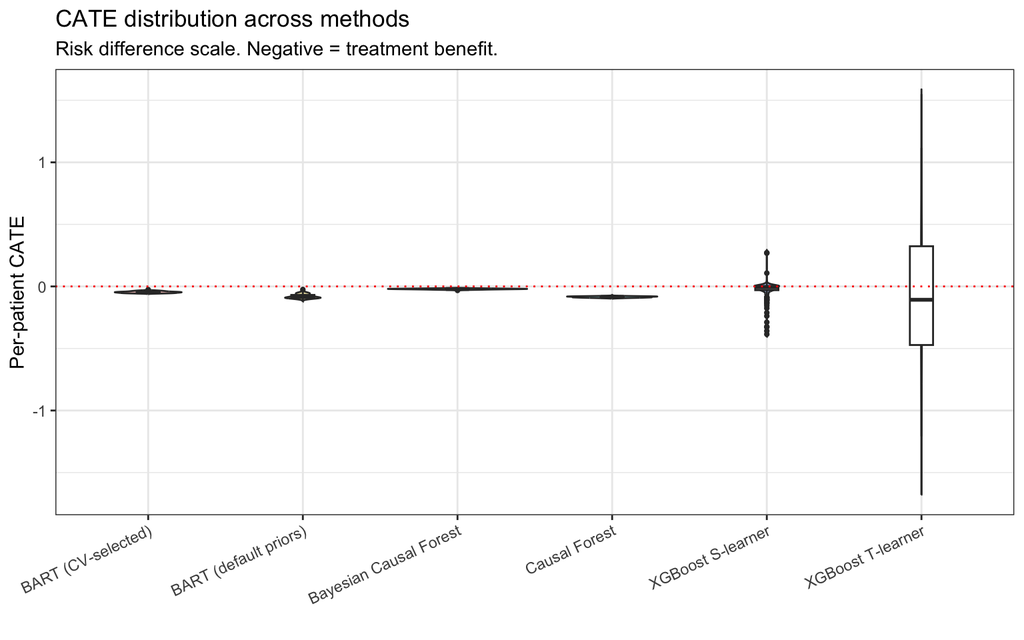

```r
overlay_df <- bind_rows(
  tibble::tibble(method = "BART (default priors)",
                 cate   = prior_results[["default"]]$cate_mean),
  tibble::tibble(method = "BART (CV-selected)",
                 cate   = prior_results[["original_cv_selected"]]$cate_mean),
  tibble::tibble(method = "Bayesian Causal Forest",
                 cate   = cate_bcf_mean),
  tibble::tibble(method = "Causal Forest",
                 cate   = cate_grf),
  tibble::tibble(method = "XGBoost T-learner",
                 cate   = cate_xgb_T),
  tibble::tibble(method = "XGBoost S-learner",
                 cate   = cate_xgb_S)
)

# Violin plots
p_full <- ggplot(overlay_df, aes(x = method, y = cate, fill = method)) +
  geom_violin(alpha = 0.4, trim = FALSE) +
  geom_boxplot(width = 0.15, fill = "white", outlier.size = 0.8) +
  geom_hline(yintercept = 0, linetype = "dotted", color = "red") +
  labs(title = "CATE distribution across methods",
       subtitle = "Risk difference scale. Negative = treatment benefit.",
       x = "",
       y = "Per-patient CATE") +
  theme_bw() +
  theme(legend.position = "none",
        axis.text.x = element_text(angle = 25, hjust = 1))
print(p_full)
```

```r
ggsave("fig_cross_method_overlay.png", p_full,
       width = 9, height = 6, dpi = 300)
```

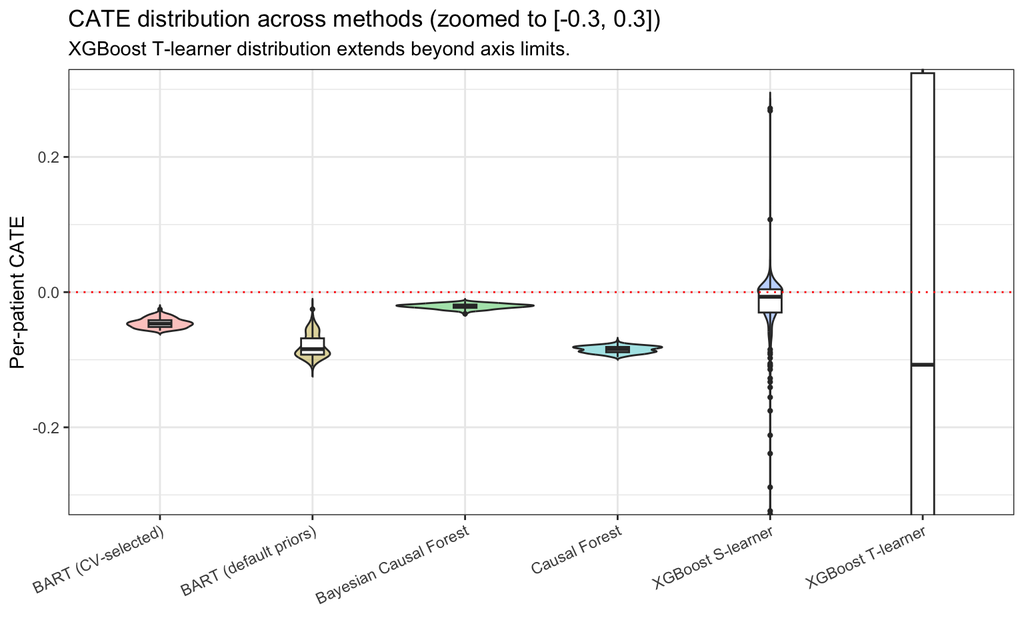

```r
# Zoomed companion: visualize regularized methods
p_zoom <- p_full +
  coord_cartesian(ylim = c(-0.3, 0.3)) +
  labs(title = "CATE distribution across methods (zoomed to [-0.3, 0.3])",
       subtitle = "XGBoost T-learner distribution extends beyond axis limits.")
print(p_zoom)
```

```r
# per-method summary table
method_summary <- overlay_df %>%
  group_by(method) %>%
  summarize(
    mean   = mean(cate),
    sd     = sd(cate),
    Q25    = quantile(cate, 0.25),
    median = median(cate),
    Q75    = quantile(cate, 0.75),
    range = paste0("[", round(min(cate), 4), ", ", round(max(cate), 4), "]"),
    .groups = "drop"
  )

knitr::kable(method_summary, digits = 4,
             caption = "Per-method CATE summary (risk difference scale)")
```

Per-method CATE summary (risk difference scale)

[output not shown]

# Treatment effect heterogeneity by baseline risk

We examine whether treatment effects vary across levels of predicted baseline mortality risk. The prognostic score is estimated from a logistic regression fit to the control arm only and applied to all patients. Two complementary analyses are conducted: (1) within-stratum risk differences across risk quartiles, and (2) BART-based CATE estimation using the prognostic score as the sole covariate, which asks whether the treatment-effect surface varies continuously with baseline risk.

## Risk-stratified treatment effect analysis

Patients are stratified into quartiles of predicted baseline risk. Within each stratum, we report the risk difference (treatment minus control) with 95% bootstrap confidence intervals. No treatment-effect model is involved in this analysis.

```r
# Fit a logistic regression on controls only to estimate baseline risk.
prog_dat  <- data.frame(y = y[!z], X[!z, ], check.names = FALSE)
prog_fit  <- glm(y ~ ., data = prog_dat, family = binomial)
risk_pred <- predict(prog_fit, newdata = X, type = "response")

# Stratify patients by quartile of predicted baseline risk
risk_q <- cut(risk_pred,
              breaks = quantile(risk_pred, probs = seq(0, 1, 0.25)),
              include.lowest = TRUE,
              labels = c("Q1 (Lowest Risk)", "Q2", "Q3", "Q4 (Highest Risk)"))

# Within-stratum unadjusted RD with bootstrap 95% CIs
B_strat <- 1000
strat_rows <- list()
for (q in levels(risk_q)) {
  idx <- which(risk_q == q)
  yq  <- y[idx]; zq <- z[idx]

  rd_q <- mean(yq[zq]) - mean(yq[!zq])

  set.seed(GLOBAL_SEED + which(levels(risk_q) == q))
  rd_boot <- replicate(B_strat, {
    bidx <- sample(idx, replace = TRUE)
    mean(y[bidx][z[bidx]]) - mean(y[bidx][!z[bidx]])
  })

  strat_rows[[q]] <- tibble::tibble(
    stratum = q,
    n = length(idx),
    n_treat = sum(zq),
    risk_diff = rd_q,
    CI_lower = quantile(rd_boot, 0.025, na.rm = TRUE),
    CI_upper = quantile(rd_boot, 0.975, na.rm = TRUE)
  )
}

strat_results <- bind_rows(strat_rows)
print(strat_results, width = Inf)
```

```
## # A tibble: 4 × 6
##   stratum               n n_treat risk_diff CI_lower CI_upper
##   <chr>             <int>   <int>     <dbl>    <dbl>    <dbl>
## 1 Q1 (Lowest Risk)     59      27    0.128   -0.0531   0.333
## 2 Q2                   59      31   -0.0991  -0.332    0.143
## 3 Q3                   58      23   -0.252   -0.498    0.0217
## 4 Q4 (Highest Risk)    59      35   -0.275   -0.484   -0.0586
```

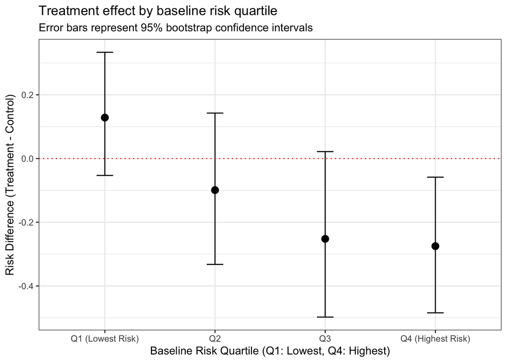

```r
ggplot(strat_results, aes(x = stratum, y = risk_diff)) +
  geom_point(size = 3) +
  geom_errorbar(aes(ymin = CI_lower, ymax = CI_upper), width = 0.15) +
  geom_hline(yintercept = 0, linetype = "dotted", color = "red") +
  labs(title = "Treatment effect by baseline risk quartile",
       subtitle = "Error bars represent 95% bootstrap confidence intervals",
       x = "Baseline Risk Quartile (Q1: Lowest, Q4: Highest)",
       y = "Risk Difference (Treatment - Control)") +
  theme_bw()
```

## 2x2 outcome tables by risk quartile

Raw outcome counts within each baseline risk stratum.

```r
for (q in levels(risk_q)) {
  idx <- which(risk_q == q)
  yq  <- y[idx]
  zq  <- z[idx]

  tab <- table(
    Arm     = factor(ifelse(zq, "ECMO", "Control"),
                     levels = c("ECMO", "Control")),
    Outcome = factor(ifelse(yq == 1, "Died", "Survived"),
                     levels = c("Survived", "Died"))
  )
  tab <- addmargins(tab)

  ev_ecmo    <- sum(yq[zq])  / sum(zq)
  ev_control <- sum(yq[!zq]) / sum(!zq)
  rd_raw     <- ev_ecmo - ev_control

  cat("\n========== Risk quartile:", q, "(n =", length(idx), ") ==========\n")
  print(tab)
  cat(sprintf("  ECMO mortality:    %d/%d = %.3f\n",
              sum(yq[zq]),  sum(zq),  ev_ecmo))
  cat(sprintf("  Control mortality: %d/%d = %.3f\n",
              sum(yq[!zq]), sum(!zq), ev_control))
  cat(sprintf("  Unadjusted RD:     %.3f\n", rd_raw))
}
```

```
##
## ========== Risk quartile: Q1 (Lowest Risk) (n = 59 ) ==========
##          Outcome
## Arm       Survived Died Sum
##   ECMO          21    6  27
##   Control       29    3  32
##   Sum           50    9  59
##   ECMO mortality:    6/27 = 0.222
##   Control mortality: 3/32 = 0.094
##   Unadjusted RD:     0.128
##
## ========== Risk quartile: Q2 (n = 59 ) ==========
##          Outcome
## Arm       Survived Died Sum
##   ECMO          23    8  31
##   Control       18   10  28
##   Sum           41   18  59
##   ECMO mortality:    8/31 = 0.258
##   Control mortality: 10/28 = 0.357
##   Unadjusted RD:     -0.099
##
## ========== Risk quartile: Q3 (n = 58 ) ==========
##          Outcome
## Arm       Survived Died Sum
##   ECMO          15    8  23
##   Control       14   21  35
##   Sum           29   29  58
##   ECMO mortality:    8/23 = 0.348
##   Control mortality: 21/35 = 0.600
##   Unadjusted RD:     -0.252
##
## ========== Risk quartile: Q4 (Highest Risk) (n = 59 ) ==========
##          Outcome
## Arm       Survived Died Sum
##   ECMO          14   21  35
##   Control        3   21  24
##   Sum           17   42  59
##   ECMO mortality:    21/35 = 0.600
##   Control mortality: 21/24 = 0.875
##   Unadjusted RD:     -0.275
```

## CATE as a function of baseline risk

We refit BART using the prognostic score as the sole covariate alongside treatment assignment. This asks whether the treatment-effect surface varies continuously with baseline risk, rather than testing at fixed quartile cutpoints.

```r
res <- fit_bart_fixed(
  X = data.frame(prog_score = risk_pred),
  y = y, z = z,
  power = 2, base = 0.95, k = 2, ntree = 200
)
```

```
## [1]  744 4148 3964   18
## [1] 2982 2379 8349 1086
```

Refit BCF with the prognostic score as the only covariate.

```r
X_prog_bcf <- matrix(risk_pred, ncol = 1)
colnames(X_prog_bcf) <- "prog_score"

pihat_prog <- fitted(glm(as.numeric(z) ~ risk_pred, family = binomial))

set.seed(GLOBAL_SEED)
sink(tempfile())
bcf_prog <- bcf::bcf(
  y          = y,
  z          = as.numeric(z),
  x_control  = X_prog_bcf,
  x_moderate = X_prog_bcf,
  pihat      = pihat_prog,
  nburn      = 2000, nsim = 2000, n_chains = 4,
  random_seed = GLOBAL_SEED, no_output = TRUE
)
sink()

mu_prog  <- bcf_prog$mu
tau_prog <- bcf_prog$tau
cate_bcf_prog_post <- pnorm(mu_prog + tau_prog) - pnorm(mu_prog)
cate_bcf_prog_mean <- colMeans(cate_bcf_prog_post)
cate_bcf_prog_lo   <- apply(cate_bcf_prog_post, 2, quantile, 0.025)
cate_bcf_prog_hi   <- apply(cate_bcf_prog_post, 2, quantile, 0.975)
```

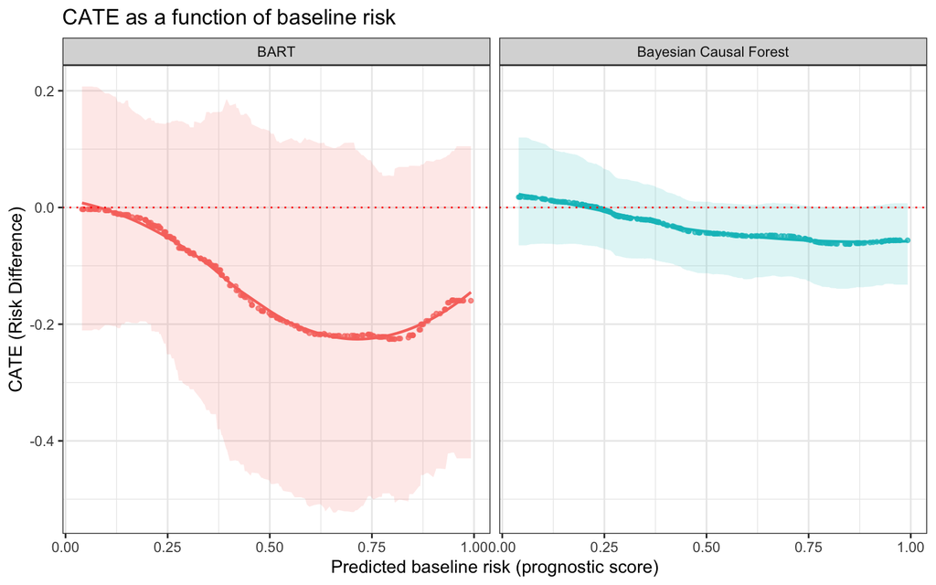

```r
risk_cate_df <- bind_rows(
  tibble::tibble(method = "BART",
                 prog_score = risk_pred,
                 cate = res$cate_mean,
                 lo = res$cate_lo, hi = res$cate_hi),
  tibble::tibble(method = "Bayesian Causal Forest",
                 prog_score = risk_pred,
                 cate = cate_bcf_prog_mean,
                 lo = cate_bcf_prog_lo, hi = cate_bcf_prog_hi)
)

p_risk_cate <- ggplot(risk_cate_df,
                      aes(x = prog_score, y = cate,
                          color = method, fill = method)) +
  geom_ribbon(aes(ymin = lo, ymax = hi), alpha = 0.15, color = NA) +
  geom_point(size = 1, alpha = 0.7) +
  geom_smooth(method = "loess", se = FALSE, linewidth = 0.8) +
  geom_hline(yintercept = 0, linetype = "dotted", color = "red") +
  facet_wrap(~ method, nrow = 1) +
  labs(x = "Predicted baseline risk (prognostic score)",
       y = "CATE (Risk Difference)",
       title = "CATE as a function of baseline risk") +
  theme_bw() +
  theme(legend.position = "none")
print(p_risk_cate)
```

### CART subgroup discovery by prognostic score

```r
cart_fit_risk <- function(point_est, posterior, X,
                               maxdepth = 3, cp = 0.01,
                               metric = c("Risk Difference", "Risk Ratio"),
                               digits = 3,
                               main = "") {
  ## point_est  : length-n vector of per-patient posterior-mean CATEs (RD or RR)
  ## posterior  : (n_draws x n_patients) matrix of posterior draws (same scale)
  ## X           : data.frame of covariates for CART splits
  ## metric      : label for titles and printed output

  metric <- match.arg(metric)

  stopifnot(ncol(posterior) == length(point_est))
  stopifnot(nrow(X) == length(point_est))

  n_total <- length(point_est)

  data_cart <- data.frame(X, outcome = point_est, check.names = FALSE)
  cartmod <- rpart(
    outcome ~ ., data = data_cart, method = "anova",
    control = rpart.control(cp = cp, maxdepth = maxdepth),
    model = TRUE
  )

  ## Precompute posterior CrI for terminal nodes only
  frame <- cartmod$frame
  node_info <- vector("list", nrow(frame))

  for (i in seq_len(nrow(frame))) {
    if (frame$var[i] != "<leaf>") next
    idx <- which(cartmod$where == i)
    if (length(idx) == 0) next
    node_avg_draws <- rowMeans(posterior[, idx, drop = FALSE])
    node_info[[i]] <- list(
      mean = mean(node_avg_draws),
      lo   = quantile(node_avg_draws, 0.025),
      hi   = quantile(node_avg_draws, 0.975),
      n    = length(idx),
      pct  = round(100 * length(idx) / n_total)
    )
  }

  ## Custom node label: CrI only for leaves, default for internal nodes
  node_label <- function(x, labs, digits, varlen) {
    fr <- x$frame
    for (i in seq_along(labs)) {
      if (fr$var[i] == "<leaf>" && !is.null(node_info[[i]])) {
        info <- node_info[[i]]
        labs[i] <- sprintf("%s\n%d%%\n95%% CrI:\n(%s, %s)",
                           formatC(info$mean, format = "f", digits = 3),
                           info$pct,
                           formatC(info$lo,   format = "f", digits = 3),
                           formatC(info$hi,   format = "f", digits = 3))
      }
    }
    labs
  }

  ## Tree with CrI labels
  rpart.plot(cartmod,
             main = main,
             yesno = 2,
             node.fun = node_label)

  ## Printed summaries
  cat("\n====", toupper(metric), "SUBGROUPS ====\n")
  for (i in unique(cartmod$where)) {
    idx <- which(cartmod$where == i)
    node_avg_draws <- rowMeans(posterior[, idx, drop = FALSE])
    node_mean <- mean(node_avg_draws)
    node_ci   <- quantile(node_avg_draws, c(0.025, 0.975))
    cat("\nNode:", i, "  n =", length(idx), "\n")
    cat("  Mean", metric, ":", round(node_mean, digits), "\n")
    cat("  95% Posterior CrI for Subgroup Mean: [",
        round(node_ci[1], digits), ",", round(node_ci[2], digits), "]\n")
  }

  invisible(cartmod)
}
```

```r
par(mfrow = c(1, 2))

cart_bart <- cart_fit_risk(
  point_est = res$cate_mean,
  posterior = res$cate_post,
  X         = data.frame(prog_score = risk_pred),
  main    = "BART"
)
```

```
##
## ==== RISK DIFFERENCE SUBGROUPS ====
##
## Node: 9   n = 68
##   Mean Risk Difference : -0.023
##   95% Posterior CrI for Subgroup Mean: [ -0.162 , 0.122 ]
##
## Node: 6   n = 17
##   Mean Risk Difference : -0.148
##   95% Posterior CrI for Subgroup Mean: [ -0.407 , 0.123 ]
##
## Node: 4   n = 88
##   Mean Risk Difference : -0.21
##   95% Posterior CrI for Subgroup Mean: [ -0.397 , -0.018 ]
##
## Node: 8   n = 41
##   Mean Risk Difference : -0.087
##   95% Posterior CrI for Subgroup Mean: [ -0.286 , 0.107 ]
##
## Node: 5   n = 21
##   Mean Risk Difference : -0.165
##   95% Posterior CrI for Subgroup Mean: [ -0.415 , 0.08 ]
```

```r
cart_bcf <- cart_fit_risk(
  point_est = cate_bcf_prog_mean,
  posterior = cate_bcf_prog_post,
  X         = data.frame(prog_score = risk_pred),
  main    = "Bayesian Causal Forest"
)
```

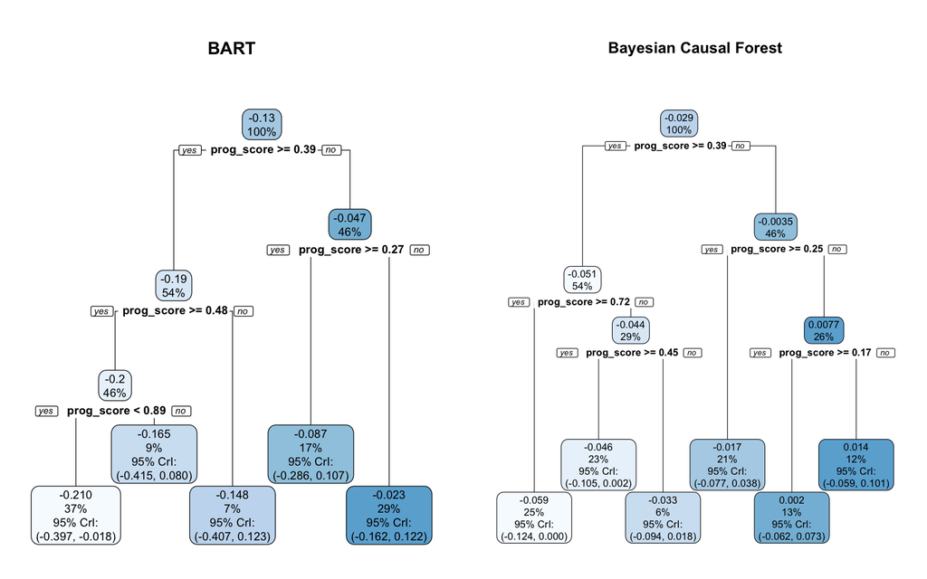

```
##
## ==== RISK DIFFERENCE SUBGROUPS ====
##
## Node: 11   n = 29
##   Mean Risk Difference : 0.014
##   95% Posterior CrI for Subgroup Mean: [ -0.059 , 0.101 ]
##
## Node: 6   n = 13
##   Mean Risk Difference : -0.033
##   95% Posterior CrI for Subgroup Mean: [ -0.094 , 0.018 ]
##
## Node: 3   n = 59
##   Mean Risk Difference : -0.059
##   95% Posterior CrI for Subgroup Mean: [ -0.124 , 0 ]
##
## Node: 8   n = 49
##   Mean Risk Difference : -0.017
##   95% Posterior CrI for Subgroup Mean: [ -0.077 , 0.038 ]
##
## Node: 5   n = 54
##   Mean Risk Difference : -0.046
##   95% Posterior CrI for Subgroup Mean: [ -0.105 , 0.002 ]
##
## Node: 10   n = 31
##   Mean Risk Difference : 0.002
##   95% Posterior CrI for Subgroup Mean: [ -0.062 , 0.073 ]
```

## Baseline profiles by risk quartile

Comparing baseline covariate profiles across risk quartiles to describe the patients in each group.

```r
# Using unscaled covariates for better interpretability
X_unscaled_with_risk <- X_unscaled %>%
  mutate(Risk_Quartile = risk_q)

X_unscaled_with_risk %>%
  tbl_summary(
    by = Risk_Quartile,
    statistic = list(all_continuous() ~ "{mean} ({sd})",
                     all_categorical() ~ "{n} ({p}%)"),
    digits = list(all_continuous() ~ 1)
  ) %>%
  add_p() %>%
  bold_labels()
```

| **Characteristic** | **Q1 (Lowest Risk)** N = 59<sup>1</sup> | **Q2** N = 59<sup>1</sup> | **Q3** N = 58<sup>1</sup> | **Q4 (Highest Risk)** N = 59<sup>1</sup> | **p-value**<sup>2</sup> |
| --- | --- | --- | --- | --- | --- |
| Age | 47.8 (13.0) | 51.9 (14.7) | 55.3 (9.7) | 57.7 (14.7) | <0.001 |
| Sexe |  |  |  |  | 0.5 |
| Man | 38 (64%) | 45 (76%) | 43 (74%) | 41 (69%) |  |
| Woman | 21 (36%) | 14 (24%) | 15 (26%) | 18 (31%) |  |
| ARDS etiology |  |  |  |  | 0.011 |
| Bacterial pneumonia | 31 (53%) | 27 (46%) | 22 (38%) | 25 (42%) |  |
| Viral pneumonia | 16 (27%) | 12 (20%) | 6 (10%) | 7 (12%) |  |
| Other | 12 (20%) | 20 (34%) | 30 (52%) | 27 (46%) |  |
| PaO2/FiO2 | 76.1 (29.4) | 76.8 (32.2) | 69.7 (25.2) | 68.8 (21.7) | 0.2 |
| PaCO2 | 54.7 (14.7) | 55.7 (14.1) | 58.3 (16.3) | 58.4 (16.5) | 0.6 |
| Vasopressors | 34 (58%) | 38 (64%) | 49 (84%) | 53 (90%) | <0.001 |
| Prone position | 39 (66%) | 37 (63%) | 31 (53%) | 32 (54%) | 0.4 |
| Recruitment maneuvers | 15 (25%) | 12 (20%) | 14 (24%) | 14 (24%) | >0.9 |
| Corticosteroids | 0 (0%) | 11 (19%) | 25 (43%) | 45 (76%) | <0.001 |
| Severe sepsis or septic shock | 35 (59%) | 48 (81%) | 47 (81%) | 51 (86%) | 0.002 |
| Immunocompromised | 0 (0%) | 2 (3.4%) | 13 (22%) | 37 (63%) | <0.001 |
| Lactate | 1.7 (1.0) | 2.1 (1.5) | 2.7 (2.0) | 4.8 (4.3) | <0.001 |
| Renal replacement therapy | 14 (24%) | 16 (27%) | 15 (26%) | 18 (31%) | 0.9 |
| SOFA score |  |  |  |  | 0.003 |
| SOFA < 11 | 32 (54%) | 35 (59%) | 21 (36%) | 18 (31%) |  |
| SOFA >= 11 | 27 (46%) | 24 (41%) | 37 (64%) | 41 (69%) |  |
| Interval between start on MV and randomization |  |  |  |  | 0.010 |
| <3 days | 45 (76%) | 30 (51%) | 44 (76%) | 40 (68%) |  |
| >= 3 days | 14 (24%) | 29 (49%) | 14 (24%) | 19 (32%) |  |
| Center |  |  |  |  | >0.9 |
| ECMO centers | 23 (39%) | 23 (39%) | 22 (38%) | 25 (42%) |  |
| No ECMO centers | 36 (61%) | 36 (61%) | 36 (62%) | 34 (58%) |  |

<sup>1</sup> Mean (SD); n (%)  
<sup>2</sup> Kruskal-Wallis rank sum test; Pearson’s Chi-squared test

## Updated CART models with restricted depth

### max depth = 1

```r
par(mfrow = c(1, 2))

# BART
cart_bart_d1 <- cart_fit_risk(
  point_est = res$cate_mean,
  posterior = res$cate_post,
  X         = data.frame(prog_score = risk_pred),
  maxdepth  = 1,
  main      = "BART (Depth 1)"
)
```

```
##
## ==== RISK DIFFERENCE SUBGROUPS ====
##
## Node: 3   n = 109
##   Mean Risk Difference : -0.047
##   95% Posterior CrI for Subgroup Mean: [ -0.184 , 0.094 ]
##
## Node: 2   n = 126
##   Mean Risk Difference : -0.194
##   95% Posterior CrI for Subgroup Mean: [ -0.359 , -0.024 ]
```

```r
# BCF
cart_bcf_d1 <- cart_fit_risk(
  point_est = cate_bcf_prog_mean,
  posterior = cate_bcf_prog_post,
  X         = data.frame(prog_score = risk_pred),
  maxdepth  = 1,
  main      = "BCF (Depth 1)"
)
```

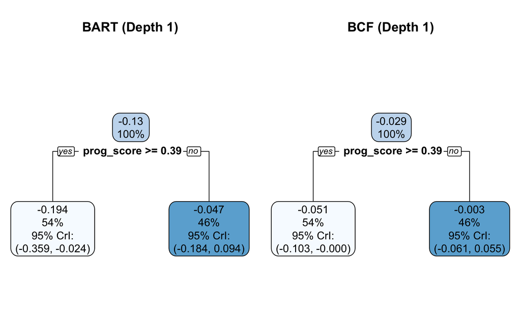

```
##
## ==== RISK DIFFERENCE SUBGROUPS ====
##
## Node: 3   n = 109
##   Mean Risk Difference : -0.003
##   95% Posterior CrI for Subgroup Mean: [ -0.061 , 0.055 ]
##
## Node: 2   n = 126
##   Mean Risk Difference : -0.051
##   95% Posterior CrI for Subgroup Mean: [ -0.103 , 0 ]
```

### max depth = 2

```r
par(mfrow = c(1, 2))

# BART
cart_bart_d2 <- cart_fit_risk(
  point_est = res$cate_mean,
  posterior = res$cate_post,
  X         = data.frame(prog_score = risk_pred),
  maxdepth  = 2,
  main      = "BART (Depth 2)"
)
```

```
##
## ==== RISK DIFFERENCE SUBGROUPS ====
##
## Node: 7   n = 68
##   Mean Risk Difference : -0.023
##   95% Posterior CrI for Subgroup Mean: [ -0.162 , 0.122 ]
##
## Node: 4   n = 17
##   Mean Risk Difference : -0.148
##   95% Posterior CrI for Subgroup Mean: [ -0.407 , 0.123 ]
##
## Node: 3   n = 109
##   Mean Risk Difference : -0.201
##   95% Posterior CrI for Subgroup Mean: [ -0.376 , -0.02 ]
##
## Node: 6   n = 41
##   Mean Risk Difference : -0.087
##   95% Posterior CrI for Subgroup Mean: [ -0.286 , 0.107 ]
```

```r
# BCF
cart_bcf_d2 <- cart_fit_risk(
  point_est = cate_bcf_prog_mean,
  posterior = cate_bcf_prog_post,
  X         = data.frame(prog_score = risk_pred),
  maxdepth  = 2,
  main      = "BCF (Depth 2)"
)
```

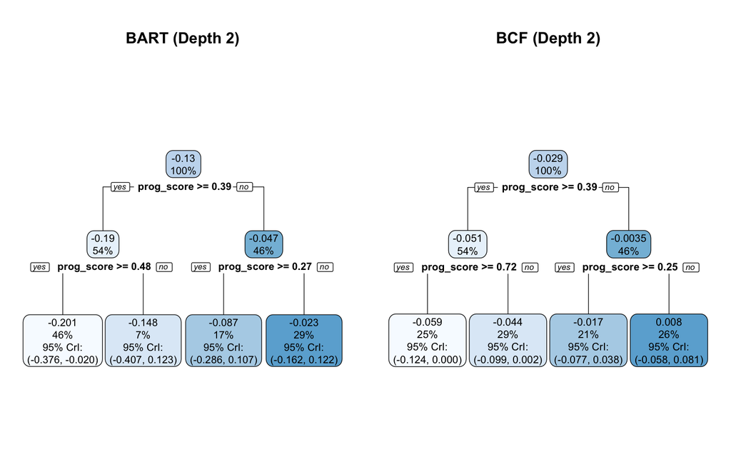

```
##
## ==== RISK DIFFERENCE SUBGROUPS ====
##
## Node: 7   n = 60
##   Mean Risk Difference : 0.008
##   95% Posterior CrI for Subgroup Mean: [ -0.058 , 0.081 ]
##
## Node: 4   n = 67
##   Mean Risk Difference : -0.044
##   95% Posterior CrI for Subgroup Mean: [ -0.099 , 0.002 ]
##
## Node: 3   n = 59
##   Mean Risk Difference : -0.059
##   95% Posterior CrI for Subgroup Mean: [ -0.124 , 0 ]
##
## Node: 6   n = 49
##   Mean Risk Difference : -0.017
##   95% Posterior CrI for Subgroup Mean: [ -0.077 , 0.038 ]
```